# **Stroke Detection and Analysis**

## **Introduction**

**What is a stroke?** Stroke is a critical medical condition that occurs when the blood supply to a part of the brain is interrupted, leading to brain damage and potential long-term disabilities.

According to the World Health Organization (WHO) strokes happen to be the second leading cause of death globally, responsible for approximately 11% of total deaths. Similar to most other medical conditions, early detection and timely treatment are crucial to improving the survival rates and reducing the impact of stroke on patients' lives. However, according to the CDC, 80% of premature heart disease and strokes are preventable. Thus, we aim to assist in preventing strokes through early detection.

This project focuses on developing machine learning models to help predict the occurrence of strokes based on various health-related/lifestyle features. The importance of this topic lies in its potential to provide healthcare professionals with advanced tools for early diagnosis and intervention, ultimately saving lives and improving the quality of care for stroke patients.

Additionally, this project serves as a comprehensive tutorial that will guide users through the entire data science pipeline, which includes:

- **[Data Curation](https://en.wikipedia.org/wiki/Data_curation), [Parsing](https://pieriantraining.com/parsing-data-in-python-a-tutorial-for-beginners/), and [Management](https://realpython.com/python-sqlite-sqlalchemy/)**: Collecting, cleaning, and organizing the data necessary for analysis.
- **[Exploratory Data Analysis](https://towardsdatascience.com/an-extensive-guide-to-exploratory-data-analysis-ddd99a03199e) (EDA)**: Understanding the data through visualization and summary statistics to identify patterns and insights.
- **[Hypothesis Testing](https://towardsdatascience.com/hypothesis-testing-with-python-step-by-step-hands-on-tutorial-with-practical-examples-e805975ea96e)**: Applying statistical tests to provide a robust analysis of the data.
- **[Machine Learning](https://towardsdatascience.com/machine-learning-introduction-a-comprehensive-guide-af6712cf68a3)**: Building and training machine learning models to provide a robust analysis of the data.
- **Curation of Insights**: Communicating the findings and insights learned during the tutorial in a clear and impactful manner.

By following this tutorial, users will gain a thorough understanding of the data science workflow, from initial data handling to the final interpretation of results, with a specific focus on stroke prediction and prevention.

#### **Preliminary Research:** Before taking a data analysis oriented approach to this topic, we wanted to gain an understanding for the topic itself and conduct some backround research so we could best figure out what angles to analyze our topic from. Here are some resources we read up on:

- [**CDC Heart Attacks and Strokes Prevention**](https://archive.cdc.gov/www_cdc_gov/vitalsigns/million-hearts/index.html#:~:text=About%2016%20million%20heart%20attacks,disease%20and%20strokes%20are%20preventable): Take a look at this link to discover more about populations at risk for stroke, learn about small lifestyle adjustments that can decrease the risk of having a stroke, and explore comprehensive recommendations for what governments, healthcare providers, and employers can do to reduce the overall incidence of strokes.
- [**What is a stroke?**](https://www.heartandstroke.ca/stroke/what-is-stroke): A stroke occurs when blood flow to a part of the brain is cut off, damaging brain cells. The impact of a stroke varies depending on which part of the brain is affected and how much damage is incurred. The two main types of stroke are Ischemic Stroke and Hemorrhagic Stroke. Explore this link to understand more about what a stroke is, including the various types of strokes and their causes.
- [**Heart Disease and Stroke**](https://www.webmd.com/stroke/stroke): Stroke symptoms include unilateral numbness or weakness, sudden vision loss, speech difficulties, severe headaches, and loss of balance. If these signs are present, you should call 911 immediately as strokes require urgent medical attention. About half of all strokes can be prevented by managing risk factors such as high blood pressure, diabetes, and smoking. However, some risks, like age, gender, and genetic predisposition, cannot be modified. Regular medical check-ups can help identify and manage these risks to prevent potential strokes. Check this link out to learn more about the symptoms of a stroke and how to recognize it in others.

Collaborators: Tara Adusumilli, Shreeya Venkatesh, Anjali Kumar, Amr Tairi

```python
import pandas as pd
import matplotlib.pyplot as plt
import seaborn as sns
from sklearn.impute import KNNImputer
from sklearn.ensemble import RandomForestClassifier
from sklearn.preprocessing import LabelEncoder
from sklearn.model_selection import train_test_split, GridSearchCV
from sklearn.preprocessing import StandardScaler
from sklearn.linear_model import LogisticRegression
from sklearn.neighbors import KNeighborsClassifier
from sklearn.model_selection import GridSearchCV
from sklearn.metrics import accuracy_score, classification_report, roc_auc_score, confusion_matrix, ConfusionMatrixDisplay
from scipy.stats import chi2_contingency
from imblearn.combine import SMOTEENN
```

## **Data Collection**

For this tutorial, we used a dataset titled "[healthcare-dataset-stroke-data.csv](https://www.kaggle.com/code/bhuvanchennoju/data-storytelling-auc-focus-on-strokes)," which we downloaded from Kaggle. The dataset includes 5110 observations, each representing a patient, with relevant input parameters such as age, hypertension, BMI, and more. Some attributes are categorical, like smoking status, while others are continuous, like BMI. Since this dataset was obtained from Kaggle, we avoided techniques like web scraping, which often lead to messy data. However, we did perform data imputation, as discussed in the next section.

### **Data Processing**

```python
df = pd.read_csv('healthcare-dataset-stroke-data.csv')
df['ever_married'] = df['ever_married'].apply(lambda x: 1 if x == 'Yes' else 0)
df.head(10)
```

|  | id | gender | age | hypertension | heart_disease | ever_married | work_type | Residence_type | avg_glucose_level | bmi | smoking_status | stroke |
| --- | --- | --- | --- | --- | --- | --- | --- | --- | --- | --- | --- | --- |
| 0 | 9046 | Male | 67.0 | 0 | 1 | 1 | Private | Urban | 228.69 | 36.6 | formerly smoked | 1 |
| 1 | 51676 | Female | 61.0 | 0 | 0 | 1 | Self-employed | Rural | 202.21 | NaN | never smoked | 1 |
| 2 | 31112 | Male | 80.0 | 0 | 1 | 1 | Private | Rural | 105.92 | 32.5 | never smoked | 1 |
| 3 | 60182 | Female | 49.0 | 0 | 0 | 1 | Private | Urban | 171.23 | 34.4 | smokes | 1 |
| 4 | 1665 | Female | 79.0 | 1 | 0 | 1 | Self-employed | Rural | 174.12 | 24.0 | never smoked | 1 |
| 5 | 56669 | Male | 81.0 | 0 | 0 | 1 | Private | Urban | 186.21 | 29.0 | formerly smoked | 1 |
| 6 | 53882 | Male | 74.0 | 1 | 1 | 1 | Private | Rural | 70.09 | 27.4 | never smoked | 1 |
| 7 | 10434 | Female | 69.0 | 0 | 0 | 0 | Private | Urban | 94.39 | 22.8 | never smoked | 1 |
| 8 | 27419 | Female | 59.0 | 0 | 0 | 1 | Private | Rural | 76.15 | NaN | Unknown | 1 |
| 9 | 60491 | Female | 78.0 | 0 | 0 | 1 | Private | Urban | 58.57 | 24.2 | Unknown | 1 |

As you can see above, there seems to be missing values for various features. For example, in the eighth observation, the bmi is NaN. Below, we are getting the unique values for each column to see how missing values are represented in the data frame. This helps with the data imputation that will be done later on. As you can see, missing values are represented as "Other" for the gender feature, "nan" for the BMI feature, and "Unknown" for the smoking status feature. Now that we know how missing data is represented, we can perform data imputation for these 3 columns.

```python
# getting unique values for each column
unique_gender = df['gender'].unique()
unique_age = df['age'].unique()
unique_hypertension = df['hypertension'].unique()
unique_heart_disease = df['heart_disease'].unique()
unique_ever_married = df['ever_married'].unique()
unique_work_type = df['work_type'].unique()
unique_Residence_type = df['Residence_type'].unique()
unique_avg_glucose_level = df['avg_glucose_level'].unique()
unique_bmi = df['bmi'].unique()
unique_smoking_status = df['smoking_status'].unique()
unique_stroke = df['stroke'].unique()

# printing unique values
print("Unique Gender:", unique_gender)
print("Unique Age:", unique_age)
print("Unique Hypertension:", unique_hypertension)
print("Unique Heart Disease:", unique_heart_disease)
print("Unique Ever Married:", unique_ever_married)
print("Unique Work Type:", unique_work_type)
print("Unique Residence Type:", unique_Residence_type)
print("Unique Average Glucose Level:", unique_avg_glucose_level)
print("Unique BMI:", unique_bmi)
print("Unique Smoking Status:", unique_smoking_status)
print("Unique Stroke:", unique_stroke)
```

```
Unique Gender: ['Male' 'Female' 'Other']
Unique Age: [6.70e+01 6.10e+01 8.00e+01 4.90e+01 7.90e+01 8.10e+01 7.40e+01 6.90e+01
 5.90e+01 7.80e+01 5.40e+01 5.00e+01 6.40e+01 7.50e+01 6.00e+01 5.70e+01
 7.10e+01 5.20e+01 8.20e+01 6.50e+01 5.80e+01 4.20e+01 4.80e+01 7.20e+01
 6.30e+01 7.60e+01 3.90e+01 7.70e+01 7.30e+01 5.60e+01 4.50e+01 7.00e+01
 6.60e+01 5.10e+01 4.30e+01 6.80e+01 4.70e+01 5.30e+01 3.80e+01 5.50e+01
 1.32e+00 4.60e+01 3.20e+01 1.40e+01 3.00e+00 8.00e+00 3.70e+01 4.00e+01
 3.50e+01 2.00e+01 4.40e+01 2.50e+01 2.70e+01 2.30e+01 1.70e+01 1.30e+01
 4.00e+00 1.60e+01 2.20e+01 3.00e+01 2.90e+01 1.10e+01 2.10e+01 1.80e+01
 3.30e+01 2.40e+01 3.40e+01 3.60e+01 6.40e-01 4.10e+01 8.80e-01 5.00e+00
 2.60e+01 3.10e+01 7.00e+00 1.20e+01 6.20e+01 2.00e+00 9.00e+00 1.50e+01
 2.80e+01 1.00e+01 1.80e+00 3.20e-01 1.08e+00 1.90e+01 6.00e+00 1.16e+00
 1.00e+00 1.40e+00 1.72e+00 2.40e-01 1.64e+00 1.56e+00 7.20e-01 1.88e+00
 1.24e+00 8.00e-01 4.00e-01 8.00e-02 1.48e+00 5.60e-01 4.80e-01 1.60e-01]
Unique Hypertension: [0 1]
Unique Heart Disease: [1 0]
Unique Ever Married: [1 0]
Unique Work Type: ['Private' 'Self-employed' 'Govt_job' 'children' 'Never_worked']
Unique Residence Type: ['Urban' 'Rural']
Unique Average Glucose Level: [228.69 202.21 105.92 ...  82.99 166.29  85.28]
Unique BMI: [36.6  nan 32.5 34.4 24.  29.  27.4 22.8 24.2 29.7 36.8 27.3 28.2 30.9
 37.5 25.8 37.8 22.4 48.9 26.6 27.2 23.5 28.3 44.2 25.4 22.2 30.5 26.5
 33.7 23.1 32.  29.9 23.9 28.5 26.4 20.2 33.6 38.6 39.2 27.7 31.4 36.5
 33.2 32.8 40.4 25.3 30.2 47.5 20.3 30.  28.9 28.1 31.1 21.7 27.  24.1
 45.9 44.1 22.9 29.1 32.3 41.1 25.6 29.8 26.3 26.2 29.4 24.4 28.  28.8
 34.6 19.4 30.3 41.5 22.6 56.6 27.1 31.3 31.  31.7 35.8 28.4 20.1 26.7
 38.7 34.9 25.  23.8 21.8 27.5 24.6 32.9 26.1 31.9 34.1 36.9 37.3 45.7
 34.2 23.6 22.3 37.1 45.  25.5 30.8 37.4 34.5 27.9 29.5 46.  42.5 35.5
 26.9 45.5 31.5 33.  23.4 30.7 20.5 21.5 40.  28.6 42.2 29.6 35.4 16.9
 26.8 39.3 32.6 35.9 21.2 42.4 40.5 36.7 29.3 19.6 18.  17.6 19.1 50.1
 17.7 54.6 35.  22.  39.4 19.7 22.5 25.2 41.8 60.9 23.7 24.5 31.2 16.
 31.6 25.1 24.8 18.3 20.  19.5 36.  35.3 40.1 43.1 21.4 34.3 27.6 16.5
 24.3 25.7 21.9 38.4 25.9 54.7 18.6 24.9 48.2 20.7 39.5 23.3 64.8 35.1
 43.6 21.  47.3 16.6 21.6 15.5 35.6 16.7 41.9 16.4 17.1 29.2 37.9 44.6
 39.6 40.3 41.6 39.  23.2 18.9 36.1 36.3 46.5 16.8 46.6 35.2 20.9 13.8
 31.8 15.3 38.2 45.2 17.  49.8 27.8 60.2 23.  22.1 26.  44.3 51.  39.7
 34.7 21.3 41.2 34.8 19.2 35.7 40.8 24.7 19.  32.4 34.  28.7 32.1 51.5
 20.4 30.6 71.9 19.3 40.9 17.2 16.1 16.2 40.6 18.4 21.1 42.3 32.2 50.2
 17.5 18.7 42.1 47.8 20.8 30.1 17.3 36.4 12.  36.2 55.7 14.4 43.  41.7
 33.8 43.9 22.7 57.5 37.  38.5 16.3 44.  32.7 54.2 40.2 33.3 17.4 41.3
 52.3 14.6 17.8 46.1 33.1 18.1 43.8 50.3 38.9 43.7 39.9 15.9 19.8 12.3
 78.  38.3 41.  42.6 43.4 15.1 20.6 33.5 43.2 30.4 38.  33.4 44.9 44.7
 37.6 39.8 53.4 55.2 42.  37.2 42.8 18.8 42.9 14.3 37.7 48.4 50.6 46.2
 49.5 43.3 33.9 18.5 44.5 45.4 55.  54.8 19.9 17.9 15.6 52.8 15.2 66.8
 55.1 18.2 48.5 55.9 57.3 10.3 14.1 15.7 56.  44.8 13.4 51.8 38.1 57.7
 44.4 38.8 49.3 39.1 54.  56.1 97.6 53.9 13.7 11.5 41.4 14.2 49.4 15.4
 45.1 49.2 48.7 53.8 42.7 48.8 52.7 53.5 50.5 15.8 45.3 14.8 51.9 63.3
 40.7 61.2 48.  46.8 48.3 58.1 50.4 11.3 12.8 13.5 14.5 15.  59.7 47.4
 52.5 13.2 52.9 61.6 49.9 54.3 47.9 13.  13.9 50.9 57.2 64.4 92.  50.8
 57.9 45.8 47.6 14.  46.4 46.9 47.1 13.3 48.1 51.7 46.3 54.1 14.9]
Unique Smoking Status: ['formerly smoked' 'never smoked' 'smokes' 'Unknown']
Unique Stroke: [1 0]
```

There are many ways to handle missing data such as k-nearest neighbors (KNN), or a random forest classifier. Assuming our missing data points are not Missing Completely At Random, dropping missing observations will bias our data. However, as shown by the bar graph below, the amount of missing gender values is very low, especially in comparison to the larger amount of observations missing for smoking status and BMI. So, we are going to drop missing gender values as it will not significantly bias our data. We will now use KNN and a random forest classifier respectively to impute the missing BMI and smoking status values.

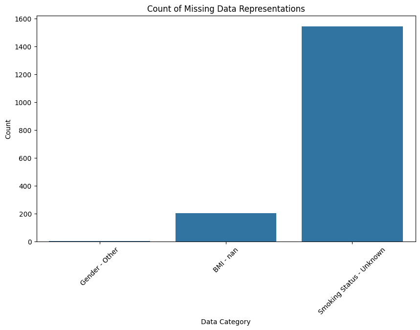

```python
other_count = (df['gender'] == 'Other').sum()
nan_count = df['bmi'].isna().sum()
unknown_count = (df['smoking_status'] == 'Unknown').sum()

# new data frame with missing data counts for each of the three columns
missing_data = pd.DataFrame({
    'Category': ['Gender - Other', 'BMI - nan', 'Smoking Status - Unknown'],
    'Counts': [other_count, nan_count, unknown_count]
})

plt.figure(figsize=(10, 6))
sns.barplot(x='Category', y='Counts', data=missing_data)
plt.title('Count of Missing Data Representations')
plt.ylabel('Count')
plt.xlabel('Data Category')
plt.xticks(rotation=45)
plt.show()
```

```python
# dropping "Other" gender values
df = df[df['gender'] != 'Other']
df.head(10)
```

|  | id | gender | age | hypertension | heart_disease | ever_married | work_type | Residence_type | avg_glucose_level | bmi | smoking_status | stroke |
| --- | --- | --- | --- | --- | --- | --- | --- | --- | --- | --- | --- | --- |
| 0 | 9046 | Male | 67.0 | 0 | 1 | 1 | Private | Urban | 228.69 | 36.6 | formerly smoked | 1 |
| 1 | 51676 | Female | 61.0 | 0 | 0 | 1 | Self-employed | Rural | 202.21 | NaN | never smoked | 1 |
| 2 | 31112 | Male | 80.0 | 0 | 1 | 1 | Private | Rural | 105.92 | 32.5 | never smoked | 1 |
| 3 | 60182 | Female | 49.0 | 0 | 0 | 1 | Private | Urban | 171.23 | 34.4 | smokes | 1 |
| 4 | 1665 | Female | 79.0 | 1 | 0 | 1 | Self-employed | Rural | 174.12 | 24.0 | never smoked | 1 |
| 5 | 56669 | Male | 81.0 | 0 | 0 | 1 | Private | Urban | 186.21 | 29.0 | formerly smoked | 1 |
| 6 | 53882 | Male | 74.0 | 1 | 1 | 1 | Private | Rural | 70.09 | 27.4 | never smoked | 1 |
| 7 | 10434 | Female | 69.0 | 0 | 0 | 0 | Private | Urban | 94.39 | 22.8 | never smoked | 1 |
| 8 | 27419 | Female | 59.0 | 0 | 0 | 1 | Private | Rural | 76.15 | NaN | Unknown | 1 |
| 9 | 60491 | Female | 78.0 | 0 | 0 | 1 | Private | Urban | 58.57 | 24.2 | Unknown | 1 |

We are using KNN to impute missing BMI values. With the KNN algorithm, we find the K nearest points using the rest of the observations, and then take the average of their BMIs to impute the missing BMI. In our case, we chose the 5 nearest data points.

```python
# data imputation for missing BMI values using KNN
imputer = KNNImputer(n_neighbors=5)
df[['bmi']] = imputer.fit_transform(df[['bmi']])
df.head(10)
```

|  | id | gender | age | hypertension | heart_disease | ever_married | work_type | Residence_type | avg_glucose_level | bmi | smoking_status | stroke |
| --- | --- | --- | --- | --- | --- | --- | --- | --- | --- | --- | --- | --- |
| 0 | 9046 | Male | 67.0 | 0 | 1 | 1 | Private | Urban | 228.69 | 36.60000 | formerly smoked | 1 |
| 1 | 51676 | Female | 61.0 | 0 | 0 | 1 | Self-employed | Rural | 202.21 | 28.89456 | never smoked | 1 |
| 2 | 31112 | Male | 80.0 | 0 | 1 | 1 | Private | Rural | 105.92 | 32.50000 | never smoked | 1 |
| 3 | 60182 | Female | 49.0 | 0 | 0 | 1 | Private | Urban | 171.23 | 34.40000 | smokes | 1 |
| 4 | 1665 | Female | 79.0 | 1 | 0 | 1 | Self-employed | Rural | 174.12 | 24.00000 | never smoked | 1 |
| 5 | 56669 | Male | 81.0 | 0 | 0 | 1 | Private | Urban | 186.21 | 29.00000 | formerly smoked | 1 |
| 6 | 53882 | Male | 74.0 | 1 | 1 | 1 | Private | Rural | 70.09 | 27.40000 | never smoked | 1 |
| 7 | 10434 | Female | 69.0 | 0 | 0 | 0 | Private | Urban | 94.39 | 22.80000 | never smoked | 1 |
| 8 | 27419 | Female | 59.0 | 0 | 0 | 1 | Private | Rural | 76.15 | 28.89456 | Unknown | 1 |
| 9 | 60491 | Female | 78.0 | 0 | 0 | 1 | Private | Urban | 58.57 | 24.20000 | Unknown | 1 |

```python
df_random_forest_classifier = df.copy(deep=True)

# encoding all categorical variables
label_encoder = LabelEncoder()
for col in ['gender', 'work_type', 'Residence_type', 'smoking_status']:
    df_random_forest_classifier[col] = label_encoder.fit_transform(df_random_forest_classifier[col])

df_random_forest_classifier.head()

# 1 -> "formerly smoked"
# 2 -> "never smoked"
# 3 -> "smokes"
```

|  | id | gender | age | hypertension | heart_disease | ever_married | work_type | Residence_type | avg_glucose_level | bmi | smoking_status | stroke |
| --- | --- | --- | --- | --- | --- | --- | --- | --- | --- | --- | --- | --- |
| 0 | 9046 | 1 | 67.0 | 0 | 1 | 1 | 2 | 1 | 228.69 | 36.60000 | 1 | 1 |
| 1 | 51676 | 0 | 61.0 | 0 | 0 | 1 | 3 | 0 | 202.21 | 28.89456 | 2 | 1 |
| 2 | 31112 | 1 | 80.0 | 0 | 1 | 1 | 2 | 0 | 105.92 | 32.50000 | 2 | 1 |
| 3 | 60182 | 0 | 49.0 | 0 | 0 | 1 | 2 | 1 | 171.23 | 34.40000 | 3 | 1 |
| 4 | 1665 | 0 | 79.0 | 1 | 0 | 1 | 3 | 0 | 174.12 | 24.00000 | 2 | 1 |

```python
# creating seperate known and unknown smoking status columns
known = df_random_forest_classifier[df_random_forest_classifier['smoking_status'] != label_encoder.transform(['Unknown'])[0]]
unknown = df_random_forest_classifier[df_random_forest_classifier['smoking_status'] == label_encoder.transform(['Unknown'])[0]]

# predicting smoking status
clf = RandomForestClassifier()
X = known.drop('smoking_status', axis=1)
Y = known['smoking_status']
clf.fit(X, Y)

pred = clf.predict(unknown.drop('smoking_status', axis=1))
df.loc[df_random_forest_classifier['smoking_status'] == label_encoder.transform(['Unknown'])[0], 'smoking_status'] = pred

# reassigning the predicted label encodings to the correct strings
def smoking_status_label_assignment(x):
    if x == 1:
        return "formerly smoked"
    elif x == 2:
        return "never smoked"
    else:
        return "smokes"

df['smoking_status'] = df['smoking_status'].apply(lambda x: smoking_status_label_assignment(x))

df.head(10)
```

|  | id | gender | age | hypertension | heart_disease | ever_married | work_type | Residence_type | avg_glucose_level | bmi | smoking_status | stroke |
| --- | --- | --- | --- | --- | --- | --- | --- | --- | --- | --- | --- | --- |
| 0 | 9046 | Male | 67.0 | 0 | 1 | 1 | Private | Urban | 228.69 | 36.60000 | smokes | 1 |
| 1 | 51676 | Female | 61.0 | 0 | 0 | 1 | Self-employed | Rural | 202.21 | 28.89456 | smokes | 1 |
| 2 | 31112 | Male | 80.0 | 0 | 1 | 1 | Private | Rural | 105.92 | 32.50000 | smokes | 1 |
| 3 | 60182 | Female | 49.0 | 0 | 0 | 1 | Private | Urban | 171.23 | 34.40000 | smokes | 1 |
| 4 | 1665 | Female | 79.0 | 1 | 0 | 1 | Self-employed | Rural | 174.12 | 24.00000 | smokes | 1 |
| 5 | 56669 | Male | 81.0 | 0 | 0 | 1 | Private | Urban | 186.21 | 29.00000 | smokes | 1 |
| 6 | 53882 | Male | 74.0 | 1 | 1 | 1 | Private | Rural | 70.09 | 27.40000 | smokes | 1 |
| 7 | 10434 | Female | 69.0 | 0 | 0 | 0 | Private | Urban | 94.39 | 22.80000 | smokes | 1 |
| 8 | 27419 | Female | 59.0 | 0 | 0 | 1 | Private | Rural | 76.15 | 28.89456 | formerly smoked | 1 |
| 9 | 60491 | Female | 78.0 | 0 | 0 | 1 | Private | Urban | 58.57 | 24.20000 | never smoked | 1 |

## **Exploratory Data Analysis**

### Part 1: Identifying factors of stroke

To start our analysis journey, we need to figure out the direction that we want to head in. What variables are considered prevalent enough for us to look further into and conduct a deeper analysis on? Are there any variables that are clearly not associated to the presence or absence of a stroke in a person. We essentially wanted to pointpoint which variables would allow us to create a story worth telling.

In order to do this, we would need a visualization that would showcase all the variables and their corresponding relationships to the presence of a stroke in a person. From here we would be able to get an idea visually of what variables should perform deeper analysis on.

##### Visualization of Stroke Occurence by **Smoking Status**, **Gender**, and **Hypertension**:

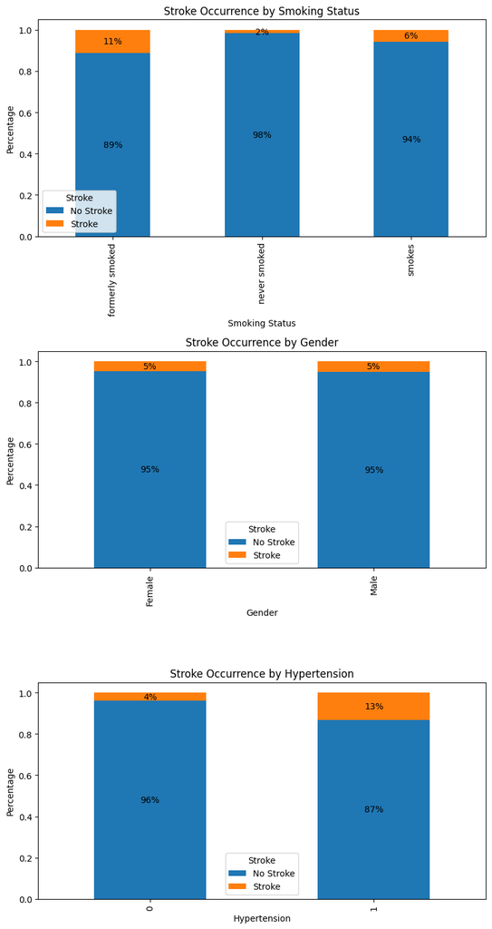

```python
fig, axs = plt.subplots(3, 1, figsize=(8, 15))

# Group data by 'smoking_status' and calculate stroke occurrence ratios
grouped_smoking = df.groupby('smoking_status')['stroke'].value_counts(normalize=True).unstack()
ax = grouped_smoking.plot(kind='bar', stacked=True, ax=axs[0])
ax.set_title('Stroke Occurrence by Smoking Status')
ax.set_xlabel('Smoking Status')
ax.set_ylabel('Percentage')
ax.legend(title='Stroke', labels=['No Stroke', 'Stroke'])
for p in ax.patches:
    width, height = p.get_width(), p.get_height()
    x, y = p.get_xy()
    ax.annotate(f'{height:.0%}', (x + width/2, y + height/2), ha='center', va='center')

# Group data by 'gender' and calculate stroke occurrence ratios
grouped_gender = df.groupby('gender')['stroke'].value_counts(normalize=True).unstack()
ax = grouped_gender.plot(kind='bar', stacked=True, ax=axs[1])
ax.set_title('Stroke Occurrence by Gender')
ax.set_xlabel('Gender')
ax.set_ylabel('Percentage')
ax.legend(title='Stroke', labels=['No Stroke', 'Stroke'])
for p in ax.patches:
    width, height = p.get_width(), p.get_height()
    x, y = p.get_xy()
    ax.annotate(f'{height:.0%}', (x + width/2, y + height/2), ha='center', va='center')

# Group data by 'hypertension' and calculate stroke occurrence ratios
grouped_hypertension = df.groupby('hypertension')['stroke'].value_counts(normalize=True).unstack()
ax = grouped_hypertension.plot(kind='bar', stacked=True, ax=axs[2])
ax.set_title('Stroke Occurrence by Hypertension')
ax.set_xlabel('Hypertension')
ax.set_ylabel('Percentage')
ax.legend(title='Stroke', labels=['No Stroke', 'Stroke'])
for p in ax.patches:
    width, height = p.get_width(), p.get_height()
    x, y = p.get_xy()
    ax.annotate(f'{height:.0%}', (x + width/2, y + height/2), ha='center', va='center')

plt.tight_layout()
plt.show()
```

Analyzing the first few variables and their relationship to the presence/absense of a stroke in a person, we can see that right off the bat there does not seem to be any significant role of gender when it comes to a person being more prone to a stroke. Of the number of females in our dataset, 5% had a stroke and of the number of males in our dataset 5% had a stroke. Since there is no difference in each of the categories, there is no need for further anyalysis in terms of investigating the role of gender and its influence in a person having a stroke.

##### Visualization of Stroke Occurence by **Age Group**

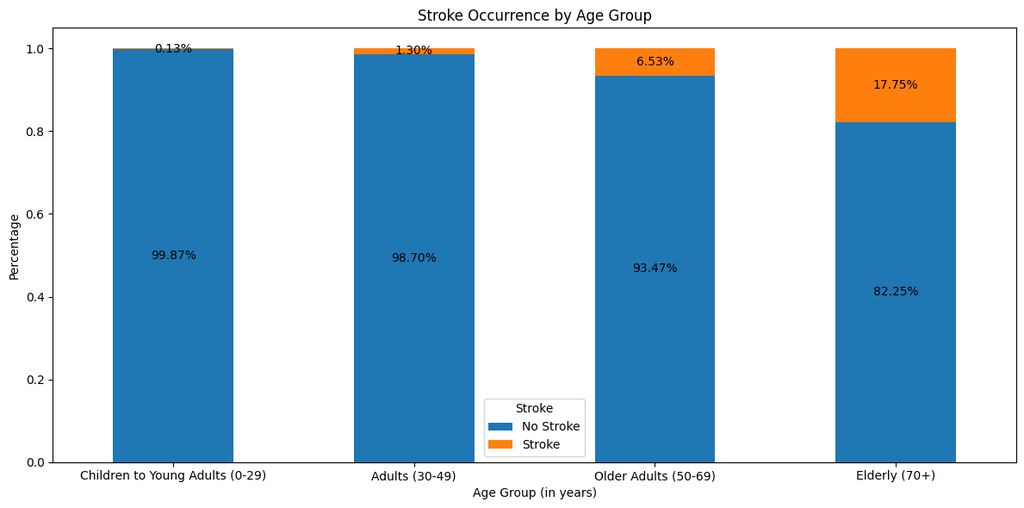

```python
# Define age categories by grouping certain age ranges together
age_bins = [0, 30, 50, 70, float('inf')]
age_labels = ['Children to Young Adults (0-29)', 'Adults (30-49)', 'Older Adults (50-69)', 'Elderly (70+)']

# Categorize age without altering the original data
df_temp = df.copy()
df_temp['age_category'] = pd.cut(df_temp['age'], bins=age_bins, labels=age_labels, right=False)

# Dataframe where we'll store the counts for each age category and stroke status and a counter dict
stroke_counts = pd.DataFrame()
counts_dict = {'No Stroke': [], 'Stroke': []}

# Loop over each age category
for label in age_labels:
    # Filter the data for the current age category
    curr_age_group = df_temp[df_temp['age_category'] == label]

    # Count the occurrences of stroke status
    no_stroke_count = curr_age_group[curr_age_group['stroke'] == 0].shape[0]
    stroke_count = curr_age_group[curr_age_group['stroke'] == 1].shape[0]

    # Append the counts to the dictionary
    counts_dict['No Stroke'].append(no_stroke_count)
    counts_dict['Stroke'].append(stroke_count)

# Convert the dictionary to a Dataframe then normalize the counts to get the percentages
stroke_counts = pd.DataFrame(counts_dict, index=age_labels)
stroke_percentages = stroke_counts.div(stroke_counts.sum(axis=1), axis=0)

# Create stacked bar graph
fig, ax = plt.subplots(figsize=(12, 6))

stroke_percentages.plot(kind='bar', stacked=True, ax=ax)

ax.set_title('Stroke Occurrence by Age Group')
ax.set_xlabel('Age Group (in years)')
ax.set_ylabel('Percentage')
ax.legend(title='Stroke', labels=['No Stroke', 'Stroke'])

# Annotate the bars with percentages
for p in ax.patches:
    width, height = p.get_width(), p.get_height()
    x, y = p.get_xy()
    ax.annotate(f'{height:.2%}', (x + width/2, y + height/2), ha='center', va='center')

# Set x-axis labels rotation to 0, so label appears horizontal
ax.set_xticklabels(ax.get_xticklabels(), rotation=0)

plt.tight_layout()
plt.show()
```

From the bar graph above, it's clear that age also plays a major role when it comes to who's suffered from a stroke. Generally, it seems that the occurence of strokes is more prevalent in age groups containing **Older Adults** (50-69 years old) and the **Elderly** (70+ years old) with **6.53%** and **17.75%** of those groups having suffered from a stroke respectively. In comparison, the occurence of strokes was extremely low in the age groups containing **Children to Young Adults** (0-29 years old) and **Adults** (30-49 years old) with **0.13%** and **1.30%** of those group having suffered from a stroke respectively. With that, we can infer that strokes are an extremely rare occurence for **Children to Young Adults**, and the older a person is, the higher the risk is for suffering from a stroke. Overall, the graph above clearly demonstrates that the likelihood of experiencing a stroke increases with age, with the highest age group in risk of suffering from a stroke being the **Elderly**

##### Visualization of Stroke occurence by **Heart Disease**, **Marriage Status**, and **Type of Work**:

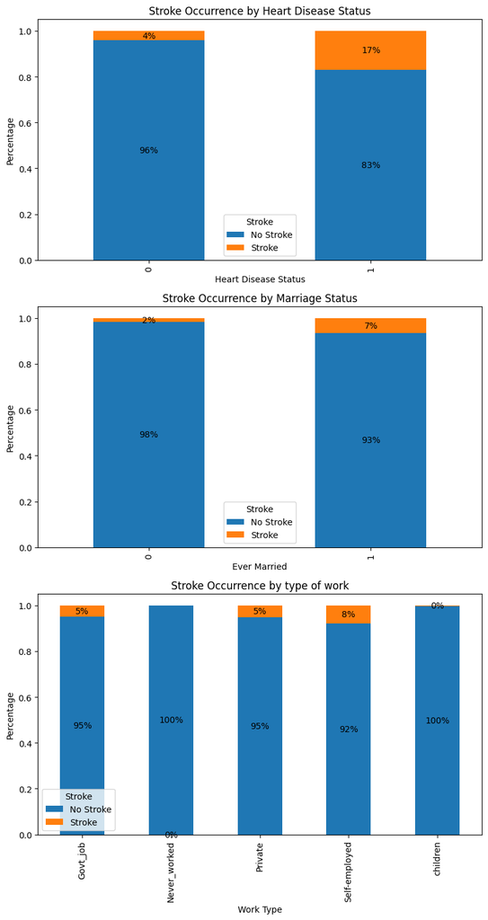

```python
fig, axs = plt.subplots(3, 1, figsize=(8, 15))

#remember that 1 indicates that the patient had a stroke and 0 indicates that the patient did not have a stroke
grouped_smoking = df.groupby('heart_disease')['stroke'].value_counts(normalize=True).unstack()
ax = grouped_smoking.plot(kind='bar', stacked=True, ax=axs[0])
ax.set_title('Stroke Occurrence by Heart Disease Status')
ax.set_xlabel('Heart Disease Status')
ax.set_ylabel('Percentage')
ax.legend(title='Stroke', labels=['No Stroke', 'Stroke'])
for p in ax.patches:
    width, height = p.get_width(), p.get_height()
    x, y = p.get_xy()
    ax.annotate(f'{height:.0%}', (x + width/2, y + height/2), ha='center', va='center')

grouped_gender = df.groupby('ever_married')['stroke'].value_counts(normalize=True).unstack()
ax = grouped_gender.plot(kind='bar', stacked=True, ax=axs[1])
ax.set_title('Stroke Occurrence by Marriage Status')
ax.set_xlabel('Ever Married')
ax.set_ylabel('Percentage')
ax.legend(title='Stroke', labels=['No Stroke', 'Stroke'])
for p in ax.patches:
    width, height = p.get_width(), p.get_height()
    x, y = p.get_xy()
    ax.annotate(f'{height:.0%}', (x + width/2, y + height/2), ha='center', va='center')


grouped_hypertension = df.groupby('work_type')['stroke'].value_counts(normalize=True).unstack()
ax = grouped_hypertension.plot(kind='bar', stacked=True, ax=axs[2])
ax.set_title('Stroke Occurrence by type of work')
ax.set_xlabel('Work Type')
ax.set_ylabel('Percentage')
ax.legend(title='Stroke', labels=['No Stroke', 'Stroke'])
for p in ax.patches:
    width, height = p.get_width(), p.get_height()
    x, y = p.get_xy()
    ax.annotate(f'{height:.0%}', (x + width/2, y + height/2), ha='center', va='center')

plt.tight_layout()
plt.show()
```

Looking at the bar graphs comparing the factors of heart disease status, marriage status, and work type relative to whether a person had a stroke or not, we can see that all of these factors could potentially play a role in determining the likelihood of a stroke. In the first graph, we see that **17%** of patients with heart disease had a stroke, while only **4%** of patients without heart disease that had a stroke. This suggests that heart disease could be a significant factor in determining the likelihood of a stroke and warrants further investigation. Additionally, looking at the second bar graph, we can see that marriage status may also play a role in determining stroke risk, though it may be a smaller factor. The difference is **7%** for patients who were married compared to **2%** for those who were not married. This indicates that marriage status could be further investigated as a potential factor, even though practically it might also be a confounding variable. Lastly, the third bar graph shows that work type might also be a significant factor in determining stroke likelihood. Among government job holders, **95%** did not have a stroke, while **5%** did. For those who never worked, **100%** did not experience a stroke. For those working in the private sector, **95%** did not have a stroke, while **5%** did. Among self-employed individuals, **92%** did not have a stroke, but **8%** did, indicating a higher risk compared to other groups. For those that took care of the children, **100%** did not experience a stroke. The differences in percentages indicate that this factor could be investigated further. Overall, these graphs highlight the potential importance of heart disease status, marriage status, and work type in assessing stroke risk, and each of these factors could benefit from a more detailed investigation.

#### Part 2: Identifying dominating contributors to stroke / Importance of certain variables in determining stroke

We have now established that gender is not that big of a factor when it comes to determining if a person has a stroke. But we have not been able to establish any of the dominating factors. What happens when a person carries characteristics that have opposite trends when it comes to determining stroke status. When a person is young but has hypertension does that mean the person will have a stroke or will their age mitigate the risk of having stroke.

Let us now look at pairs of variables and their relationship to stroke and see if the general trend for both variables holds on the data or if one trend overpowers the other. The goal with doing this is to see if we can narrow our focus on what features we should explore further and build our model around by identifying the most important contributors to stroke detection.

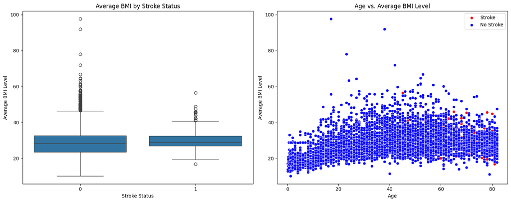

```python
plt.figure(figsize=(15, 6))

plt.subplot(1, 2, 1)
sns.boxplot(x='stroke', y='bmi', data=df)
plt.title('Average BMI by Stroke Status')
plt.xlabel('Stroke Status')
plt.ylabel('Average BMI Level')

plt.subplot(1, 2, 2)
sns.scatterplot(data=df[df['stroke'] == 1], x="age", y="bmi", color='red', label='Stroke')
sns.scatterplot(data=df[df['stroke'] == 0], x="age", y="bmi", color='blue', label='No Stroke')
plt.title('Age vs. Average BMI Level')
plt.xlabel('Age')
plt.ylabel('Average BMI Level')
plt.legend()

plt.tight_layout()
```

Now knowing that a high BMI is an indicator of stroke in the future, we wanted to see what the relationship between BMI and stroke would be if age was a factor and how much more pronounced the range in data points would be when comparing the two groups of stroke vs no stroke. We can see that now BMI doesn't seem to play as big of a role when combined with the age variable. Here the trend seems to be that the rightside of the graph(i.e the datapoints corresponding to a higher age in a person) highly correlated to more stroke and there did not seem to be any indcator that a lower or higher BMI played a significant role. We did not see any trends where the upper rightside had more datapoints where stroke was experienced in a person, which is something that we were expectingto see given the trend we saw in the BMI graph. This trend suggests that age is a more dominating factor when it comes to determining wheter a person will have stroke or not. Knowing this let us now figure out what some of the other dominating factors are when it comes to determining stroke.

##### Knowing that age is a dominating factor over BMI does it also dominate over some of the trends observed as a contributor to stroke, such as Work Type and Smoking Status?

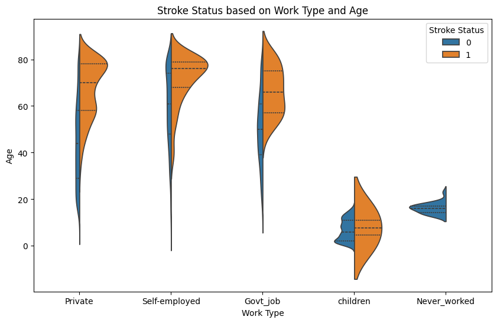

```python
plt.figure(figsize=(10, 6))
sns.violinplot(x='work_type', y='age', hue='stroke', data=df, split=True, inner="quartile")
plt.title('Stroke Status based on Work Type and Age')
plt.xlabel('Work Type')
plt.ylabel('Age')
plt.legend(title='Stroke Status')
plt.show()
```

Knowing this, let's carry out one final test and see the relationship between wheter smoking, age and stroke status all hold to their respective general trends among all the data

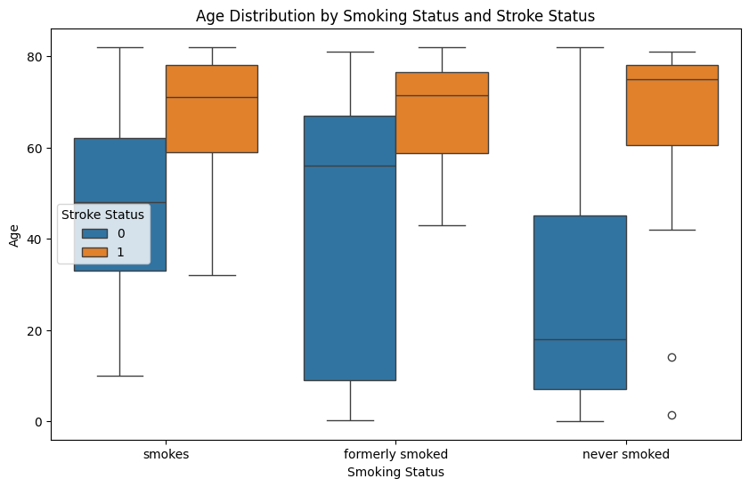

```python
plt.figure(figsize=(10, 6))
sns.boxplot(x='smoking_status', y='age', hue='stroke', data=df)
plt.title('Age Distribution by Smoking Status and Stroke Status')
plt.xlabel('Smoking Status')
plt.ylabel('Age')
plt.legend(title='Stroke Status')
plt.show()
```

It is interesting to note that the older age trend is again consistent when paired with the smoking status variable. We can see that among the data points corresponding to a stroke, the majority of their data lies in the range of 60 and beyond. But it is interesting to note that in the category of someone who has never smoked before, the mean age for which the people in that group have a stroke is a lot higher than those currently smoking or have previously smoked, once again keeping up with the trend that those who do not smoke have less of a risk of getting a stroke and generally get it way later in life than those who do. Among the two categories of smokes and formerly smoked however, there does seem to be a slight difference in the regard that it seems those who have formerly smoked as opposed to those currently smoking tend to suffer from a stroke later in life, which again makes sense as that means they have switched to a healthier lifestyle. In this analysis, we can see that the trend with smoking status is consistent even when paired with age so we can identify smoking as another dominating factor when taking into consideration if a person is to get a stroke or not.

## **Hypothesis Testing**

We will now conduct a series of hypothesis tests to determine if the factors we suspect influence the occurrence of strokes in individuals actually do. Here are the potential factors that we identified through our graphical visualizations earlier:

- smoking status
- hypertension
- heart disease
- marriage status
- work type
- age (dominating factor for BMI)

**Test #1: Is an individual's smoking status associated with them having a stroke or not?**

- **Null Hypothesis:** There is no significant association between smoking status and stroke.
- **Alternative Hypothesis:** There is a significant association between smoking status and stroke.

```python
contingency_table = pd.crosstab(df['smoking_status'], df['stroke'])

# chi-squared test of independence
# storing chi-squared statistic, degrees of freedom, p-value, and the expected frequencies of the amount of individuals who have each type of smoking status based on whether they have had a stroke or not (assuming the null)
chi2, p_value, dof, expected = chi2_contingency(contingency_table)

print("P-value:", p_value)
```

```
P-value: 1.4490079488849658e-11
```

**Test #2: Is hypertension associated with an individual having a stroke?**

- **Null Hypothesis:** There is no association between hypertension and the likelihood of having a stroke.
- **Alternative Hypothesis:** There is an association between hypertension and the likelihood of having a stroke.

```python
contingency_table = pd.crosstab(df['hypertension'], df['stroke'])

# chi-squared test of independence
# storing chi-squared statistic, degrees of freedom, p-value, and the expected frequencies of the amount of individuals who have hypertension based on whether they have had a stroke or not (assuming the null)
chi2, p_value, dof, expected = chi2_contingency(contingency_table)

print("P-value:", p_value)
```

```
P-value: 1.688936253410575e-19
```

- **Result:** The chi-square test of independence yielded a p-value of 1.688936253410575e-19, which is also very low. Again, the p-value is significantly below conventional thresholds, so we reject the null hypothesis, and have significant evidence of an association between an individual having hypertension and having a stroke.

**Test #3: Is heart disease associated with an individual having a stroke?** -**Null Hypothesis:** There is no association between heart disease and the likelihood of having a stroke.

- **Alternative Hypothesis:** There is an association between heart disease and the likelihood of having a stroke.

```python
contingency_table = pd.crosstab(df['heart_disease'], df['stroke'])

# chi-squared test of independence
# storing chi-squared statistic, degrees of freedom, p-value, and the expected frequencies of the amount of individuals who have heart disease based on whether they have had a stroke or not (assuming the null)
chi2, p_value, dof, expected = chi2_contingency(contingency_table)

print("P-value:", p_value)
```

```
P-value: 2.120831133146208e-21
```

- **Result:** The chi-square test of independence yielded a low p-value of 2.120831133146208e-21, which is significantly below conventional thresholds. Thus, reject the null hypothesis, and have significant evidence of an association between an individual having heart disease and having a stroke.

**Test #4: Is marriage status associated with an individual having a stroke?**

- **Null Hypothesis:** An individual having been married is not associated with the likelihood of having a stroke.
- **Alternative Hypothesis:** An individual having been married is associated with the likelihood of having a stroke.

```python
contingency_table = pd.crosstab(df['ever_married'], df['stroke'])

# chi-squared test of independence
# storing chi-squared statistic, degrees of freedom, p-value, and the expected frequencies of the amount of individuals who have been married based on whether they have had a stroke or not (assuming the null)
chi2, p_value, dof, expected = chi2_contingency(contingency_table)

print("P-value:", p_value)
```

```
P-value: 1.6862856191673454e-14
```

- **Result:** The chi-square test of independence yielded a low p-value of 1.6862856191673454e-14. Yet again the p-value is below conventional thresholds and we reject the null hypothesis. We have significant evidence of an association between an individual having been married and having a stroke. As previously mentioned, this is most likely a confounding variable.

**Test #5: Is the type of work an individual does associated with them having a stroke?**

- **Null Hypothesis:** The type of work an individual does is not associated with the likelihood of having a stroke.
- **Alternative Hypothesis:** The type of work an individual does is associated with the likelihood of having a stroke.

```python
contingency_table = pd.crosstab(df['work_type'], df['stroke'])

# chi-squared test of independence
# storing chi-squared statistic, degrees of freedom, p-value, and the expected frequencies of the amount of individuals who have a variety of working lifestyles based on whether they have had a stroke or not (assuming the null)
chi2, p_value, dof, expected = chi2_contingency(contingency_table)

print("P-value:", p_value)
```

```
P-value: 5.40903546949726e-10
```

- **Result:** The chi-square test of independence yielded a low p-value of 5.40903546949726e-10. Similarly to the previous factors the p-value is below conventional thresholds and we reject the null hypothesis. We have significant evidence of an association between an individual's work type and having a stroke.

**Test #6: Is an individual's age group associated with them having a stroke?**

- **Null Hypothesis:** An individual's age group is not associated with them having a stroke.
- **Alternative Hypothesis:** An individual's age group is associated with them having a stroke.

```python
# using df_temp instead of df because it has the 'age_category' factor
contingency_table = pd.crosstab(df_temp['age_category'], df_temp['stroke'])

# chi-squared test of independence
# storing chi-squared statistic, degrees of freedom, p-value, and the expected frequencies of the amount of individuals in each age group based on whether they have had a stroke or not (assuming the null)
chi2, p_value, dof, expected = chi2_contingency(contingency_table)

print("P-value:", p_value)
```

```
P-value: 3.0675362834550633e-84
```

- **Result:** For our last HP test, the chi-square test of independence again yielded a low p-value of 3.0675362834550633e-84, meaningg we reject the null hypothesis and have significant evidence of an association between an individual's age group and having a stroke.

**Final Thoughts on Hypothesis Testing:**

Now that we have conducted hypothesis tests on various suspected factors linked to stroke in an individual, we can now delve deeper into these relationships in the next section using machine learning. Our analysis confirmed significant associations between the above factors and the likelihood of stroke in an indivudal. This is shown by the really low p-values yielded by all the tests.

## **Machine Learning**

Now that we've identfied and verified the most relevant features for stroke occurence, let's leverage them to build and evaluate different predictive models. For this section, let's focus on these three classification models: **Logistic Regression**, **Random Forest**, and **K-Nearest Neighbors** (KNN). We chose these models for their interpretability, balance of simplicity, and ability to handle complex relationships in the data.

```python
# Dynamically select columns created by one-hot encoding the categorical features
one_hot_encoded_features = [col for col in df.columns if 'work_type_' in col or 'smoking_status_' in col]
# Define features and target
features = ['age', 'hypertension', 'heart_disease', 'ever_married', 'bmi'] + one_hot_encoded_features
X = df[features]
y = df['stroke']
```

##### Before building our models, let's define a function that's able to evaluate the performance of each model

The **evaluateModel()** function evaluates the given model on testing data then prints and returns key performance metrics including accuracy, classification report, and ROC-AUC score. Additionally, confusion matrices will be generated to visualize the performance of each model

```python
def evaluateModel(name, model, X_test, y_test, y_pred, y_pred_proba):

    # Calculate accuracy, ROC-AUC, then generate classification report and confusion matrix
    accuracy = accuracy_score(y_test, y_pred)
    roc_auc = roc_auc_score(y_test, y_pred_proba)
    class_report = classification_report(y_test, y_pred)
    # To return the percision, recall, and f1-score values
    class_report_dict = classification_report(y_test, y_pred, output_dict=True)
    cm = confusion_matrix(y_test, y_pred)

    # Store percision, recall, and f1-score metrics from classification report
    precision = class_report_dict['1']['precision']
    recall = class_report_dict['1']['recall']
    f1_score = class_report_dict['1']['f1-score']

    # Print evaluation metrics
    print(f"\n{name}:")
    print(f'Accuracy: {accuracy:.2f}')
    print(f'ROC-AUC: {roc_auc:.2f}')
    print(f'Classification Report:')
    print(class_report)

    # Display the confusion matrix
    ConfusionMatrixDisplay(confusion_matrix=cm, display_labels=['No Stroke', 'Stroke']).plot()
    plt.title(f'Confusion Matrix for {name}')
    plt.show()

    return {
        'model': model,
        'accuracy': accuracy,
        'roc_auc': roc_auc,
        'precision': precision,
        'recall': recall,
        'f1_score': f1_score,
        'classification_report': class_report,
        'classification_report_dict': class_report_dict,
        'confusion_matrix': cm
    }
```

### **Logistic Regression Model**

##### The **trainLRModel()** function trains a Logistic Regression model on the provided training data and evaluates it on the test data

```python
def trainLRModel(X_train, X_test, y_train, y_test):
    # Build and train a Logistic Regression model on provided training data
    model = LogisticRegression(class_weight='balanced')
    model.fit(X_train, y_train)

    # Make predictions using testing set
    y_pred = model.predict(X_test)  # Predict on test data
    # Get predicted probabilities for ROC-AUC
    y_pred_proba = model.predict_proba(X_test)[:, 1]

    results = evaluateModel('Logistic Regression', model, X_test, y_test, y_pred, y_pred_proba)
    return results
```

##### Let's evaluate the Logistic Regression model's performance:

**Note:** Since there is a large discrepancy in stroke cases in our data (there are more people who haven't suffered from a stroke than those who have) we have to balance the dataset to improve the model's performance. We chose to do this through SMOTEENN, which combines SMOTE and ENN to both oversample the minority class and clean the majority class. This combination helps balance the dataset while also improving the quality of the training data by removing potential noise and outliers

```
Logistic Regression:
Accuracy: 0.72
ROC-AUC: 0.83
Classification Report:
              precision    recall  f1-score   support

           0       0.98      0.72      0.83       960
           1       0.16      0.82      0.26        62

    accuracy                           0.72      1022
   macro avg       0.57      0.77      0.55      1022
weighted avg       0.93      0.72      0.79      1022
```

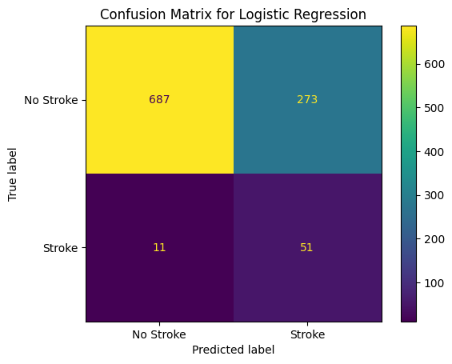

```python
# Split up the data into training and testing sets
X_train, X_test, y_train, y_test = train_test_split(X, y, test_size=.2, random_state=42)

# Apply SMOTEENN to balance the training data
smote_enn = SMOTEENN(random_state=42)
X_train, y_train = smote_enn.fit_resample(X_train, y_train)

# Build and evaluate the Logistic Regression model
resultsLRModel = trainLRModel(X_train, X_test, y_train, y_test)
```

### **Random Forest Model**

##### The **trainRFModel()** function trains a Random Forest model on the provided training data and evaluates it on the test data

```python
def trainRFModel(X_train, X_test, y_train, y_test):
    # Build and train a Random Forest model on provided training data
    model = RandomForestClassifier(random_state=42, class_weight='balanced')
    model.fit(X_train, y_train)
    # Make predictions using testing set
    y_pred = model.predict(X_test)
    # Get predicted probabilities for ROC-AUC
    y_pred_proba = model.predict_proba(X_test)[:, 1]

    results = evaluateModel('Random Forest', model, X_test, y_test, y_pred, y_pred_proba)
    return results
```

##### Let's evaluate the Random Forest model's performance:

```
Random Forest:
Accuracy: 0.81
ROC-AUC: 0.83
Classification Report:
              precision    recall  f1-score   support

           0       0.97      0.82      0.89       960
           1       0.18      0.65      0.29        62

    accuracy                           0.81      1022
   macro avg       0.58      0.73      0.59      1022
weighted avg       0.92      0.81      0.85      1022
```

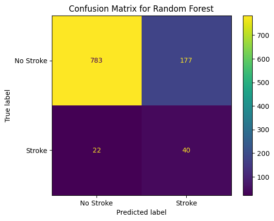

```python
# Split up the data into training and testing sets
X_train, X_test, y_train, y_test = train_test_split(X, y, test_size=.2, random_state=42)

# Standardize data to ensure that each feature contributes equally to the model, which can improve the overall performance
scaler = StandardScaler()
X_train = scaler.fit_transform(X_train)  # Fit and transform on training data
X_test = scaler.transform(X_test)  # Transform test data using the same scaler

# Apply SMOTEENN to balance the training data
smote_enn = SMOTEENN(random_state=42)
X_train, y_train = smote_enn.fit_resample(X_train, y_train)

# Build and evaluate the Logistic Regression model
resultsRFModel = trainRFModel(X_train, X_test, y_train, y_test)
```

### **K-Nearest Neighbors (KNN) Model**

##### The **trainKNNModel()** function trains a K-Nearest Neighbors model on the provided training data and evaluates it on the test data. It utilizes **GridSearchCV** to determine the optimal number of neighbors (k) for enhanced performance.

```python
def trainKNNModel(X_train, X_test, y_train, y_test):

    # Use GridSearchCV to find the best k for KNN
    param_grid = {'n_neighbors': range(1, 31)}  # Define parameter grid for k
    grid_search = GridSearchCV(KNeighborsClassifier(), param_grid, cv=5, scoring='roc_auc')

    # Perform grid search on training data then get the best k
    grid_search.fit(X_train, y_train)
    best_k = grid_search.best_params_['n_neighbors']

    # Print resulting best k
    print(f'Best k for KNN: {best_k}')

    # Build and train a KNN model on provided training data
    model = KNeighborsClassifier(n_neighbors=best_k)
    model.fit(X_train, y_train)
    # Make predictions using testing set
    y_pred = model.predict(X_test)
    # Get predicted probabilities for ROC-AUC
    y_pred_proba = model.predict_proba(X_test)[:, 1]

    results = evaluateModel('K-Nearest Neighbors', model, X_test, y_test, y_pred, y_pred_proba)
    return results
```

##### Let's evaluate the K-Nearest Neighbors model's performance:

```
Best k for KNN: 6

K-Nearest Neighbors:
Accuracy: 0.78
ROC-AUC: 0.75
Classification Report:
              precision    recall  f1-score   support

           0       0.97      0.79      0.87       960
           1       0.16      0.60      0.25        62

    accuracy                           0.78      1022
   macro avg       0.56      0.69      0.56      1022
weighted avg       0.92      0.78      0.83      1022
```

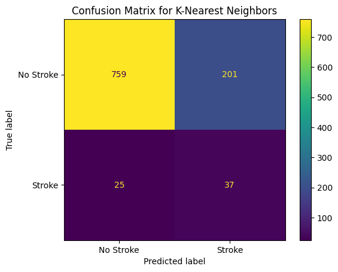

```python
# Split up the data into training and testing sets
X_train, X_test, y_train, y_test = train_test_split(X, y, test_size=.2, random_state=42)

# Apply SMOTEENN to balance the training data
smote_enn = SMOTEENN(random_state=42)
X_train, y_train = smote_enn.fit_resample(X_train, y_train)

# Build and evaluate the Logistic Regression model
resultsKNNModel = trainKNNModel(X_train, X_test, y_train, y_test)
```

### **Model Performance Comparison:**

```python
import math
# Collect metrics in a dictionary
results = {
    "Model": ["Logistic Regression", "Random Forest", "K-Nearest Neighbors"],
    "Accuracy": [resultsLRModel['accuracy'], resultsRFModel['accuracy'], resultsKNNModel['accuracy']],
    "Precision": [resultsLRModel['classification_report_dict']['1']['precision'], resultsRFModel['classification_report_dict']['1']['precision'], resultsKNNModel['classification_report_dict']['1']['precision']],
    "Recall": [resultsLRModel['classification_report_dict']['1']['recall'], resultsRFModel['classification_report_dict']['1']['recall'], resultsKNNModel['classification_report_dict']['1']['recall']],
    "F1": [resultsLRModel['classification_report_dict']['1']['f1-score'], resultsRFModel['classification_report_dict']['1']['f1-score'], resultsKNNModel['classification_report_dict']['1']['f1-score']],
    "AUC": [resultsLRModel['roc_auc'], resultsRFModel['roc_auc'], resultsKNNModel['roc_auc']]
}
# Round values to nearest integer for better readability
results["Accuracy"] = [math.ceil(acc * 100) / 100 for acc in results["Accuracy"]]
results["Precision"] = [math.ceil(acc * 100) / 100 for acc in results["Precision"]]
results["Recall"] = [math.ceil(acc * 100) / 100 for acc in results["Recall"]]
results["F1"] = [math.ceil(acc * 100) / 100 for acc in results["F1"]]
results["AUC"] = [math.ceil(acc * 100) / 100 for acc in results["AUC"]]

results_df = pd.DataFrame(results)
# Display the DataFrame as a table
display(results_df)
```

|  | Model | Accuracy | Precision | Recall | F1 | AUC |
| --- | --- | --- | --- | --- | --- | --- |
| 0 | Logistic Regression | 0.73 | 0.16 | 0.83 | 0.27 | 0.83 |
| 1 | Random Forest | 0.81 | 0.19 | 0.65 | 0.29 | 0.84 |
| 2 | K-Nearest Neighbors | 0.78 | 0.16 | 0.60 | 0.25 | 0.75 |

#### **Explanation of Metrics:**

1. **Accuracy**:
   - **Definition**: The ratio of correctly predicted instances to the total instances.
   - **Significance**: It provides an overall measure of the model's performance but can be misleading in cases of imbalanced datasets, as it doesn't differentiate between the types of errors made.
2. **Precision**:
   - **Definition**: The ratio of true positive predictions to the total positive predictions (true positives + false positives).
   - **Significance**: It indicates how many of the positive predictions made by the model are actually correct. High precision means fewer false positives, which is crucial in medical diagnostics to avoid unnecessary treatments.
3. **Recall (Sensitivity)**:
   - **Definition**: The ratio of true positive predictions to the total actual positives (true positives + false negatives).
   - **Significance**: It measures the model's ability to correctly identify all relevant instances (strokes). High recall is important in medical diagnostics to ensure that most actual stroke cases are identified.
4. **F1 Score**:
   - **Definition**: The harmonic mean of precision and recall.
   - **Significance**: It provides a single metric that balances precision and recall, useful when you need a balance between false positives and false negatives.
5. **AUC (Area Under the Curve)**:
   - **Definition**: The area under the ROC curve, which plots the true positive rate against the false positive rate at various threshold settings.
   - **Significance**: It measures the model's ability to distinguish between classes. Higher AUC indicates better performance in distinguishing stroke from non-stroke cases.

#### **Analysis:**

After observing the performance metrics of the three models, it's clear that they all possess varying strengths and weaknesses. For instance, the **Logistic Regression Model** shows a good balance between accuracy (0.73) and AUC (0.83), with the highest recall out of all models (0.83). This means it is the most effective at identifying actual stroke cases but has a relatively low precision (0.16), leading to many false positives. Therefore, this model is preferable when the priority is to ensure all stroke cases are identified, even at the expense of some false alarms.

Finally, the **K-Nearest Neighbors (KNN) Model** had the second highest accuracy (0.78), but also the lowest AUC (0.75) compared to our other models. Additionally, it also has the lowest recall (0.60), meaning that it misses the most stroke cases but its precision (0.16) is approximately the same as that of the Logistic Regression Model. Therefore, this indicates that KNN might not be as effective in identifying stroke cases as the other two models, as it had the worst overall performance metrics.

#### **Note Regarding Model Optimization Strategies:**

Although it seems that the performances of the models aren't exceptional, they could be much worse. First, it's important to note that there is a huge discrepancy in our data when it comes to those who've suffered from a stroke and those who haven't. With that said, before training the models, we had to balance the dataset to improve the model's performance. We chose to do this through SMOTEENN, which combines SMOTE and ENN to both oversample the minority class and clean the majority class. This combination helps balance the dataset while also improving the quality of the training data by removing potential noise and outliers. Additionally, for the Random Forest Model, we standardized our data to ensure that each feature contributes equally to the model, which also helped improve the overall performance. However, there is certainly room for improvement in the future like incorporating a larger dataset or using more complex machine learning algorithms.

#### **Conclusions/ Final Observations:**

Having written this notebook we have gained a greater understanding of what a healthy lifestyle looks like. There are many factors that contribute to many different illnesses and with stroke being such a prevalent cause of death in the United States, it is important to really understand what is the causes of stroke.

For more information on risks and factors of stroke, please refer to: https://www.nhlbi.nih.gov/health/stroke/causes#:~:text=Ischemic%20and%20hemorrhagic%20strokes%20share,disease%2C%20and%20carotid%20artery%20disease. This was a resource that served as an inspiration for our notebook in terms of corroborating our lens of focus and the variables we decided to analyze as factors of stroke.

With our initial analysis we saw that a lot of the variables that we were examining were actually fairly related to the presence of stroke in a person. That said there were a few variables that we ruled out as not being correlated at all upon visual analysis. One of these factors, that was surprising to us as not being included as a cause of stroke, was gender. Oftentimes, it is the case that males are more prone to certain illnesses compared to females and vice versa, so seeing that this was not the case for stroke was something that was surprising to us as we were writing this notebook. Something else that we found to be interesting was that BMI was not as big of a factor when it came to the importance of other variables such as age, suggesting that some factors may be out of our control when it comes to preventing stroke, but other such as smoking status is something that is very much in our control.

When conducting our hypothesis testing, we only conducted tests for the features that we hypothesized were related to stroke based on our visual analysis, and we concluded that everything that seemed to visually be a direct contributor to stroke in a person did in fact statistically prove to be a contributor. These main factors included: smoking status, hypertension, heart disease, age, marriage status, and work type.

#### **Next Steps:**

For the next steps in our model, we would like to look at more factors of stroke in order to improve our models. There are obviously a lot more factors that could serve as contributors to whether a person has a stroke or not such as race, geographic location, wealth status, etc that would prove to be useful in our predictive models. Right now our models have a decent accuracy but since our F1 and precision are not that high that indicates we need to include more factors in our model to serve as features in our predictive function.